# SML201 Chapter 4.2

Central Limit Theorem

Daisy Huang

Fall 2019

# Introduction

In this chapter we will show you how to take into account the sample variation when making estimate of a population parameter.

# The (Hypothetical) problem that we are trying to solve

**Problem needed to be solved** Suppose that the company Nike is trying to decide if it should run a promotion targeting undergraduate athletes. Part of the company’s decision depends on the percentage of undergrads that are athletes in the U.S. You are hired by Nike as an intern and your job is to figure this percentage out for the company. Nike would like you to spend as little as possible but would also like you to provide a number that is accurate. You need to spend your resource wisely.

**Background information** There are about 17 million students in all the degree-granting postsecondary institutions in 2017 in the U.S.

(https://nces.ed.gov/programs/coe/indicator_cha.asp).

**Limitation** Surely you don’t have the time or the resource to ask every single student whether she/he is an athlete or not. What can you do?

# Possible approach

We can select a few students to see if they are athletes. Let’s draw a simple random sample of 19 students from all the students in the U.S. degree-granting postsecondary institutions.

## Identify the population and the sample

1. In the context of this problem the population consist of

```
a.) all the undergraduate students in the U.S.
b.) all the undergraduate students in the U.S. who are athletes
c.) the 19 students that we selected
```

Answer:

2. The percentage of U.S. undergraduates who are athletes is

```
a.) a paramenter
b.) a statistic
c.) neither a parameter or a statistics
```

Answer:

## How do you record the data?

## Now each of us draw a sample!

You should run the line below only ONCE to get your sample (you do not have enough fund/time/human_power to collect more than one sample).

```r
my.sample = as.numeric((rpois(n = 19, lambda = 1.5) + rpois(n = 19,
    lambda = 3) + rpois(n = 19, lambda = 0.2)) > 6)
```

## How does your sample compared to your neighbors’?

Note that no matter how you select the objects unless you are selecting everyone in the population, there are always random variations in the sample.

Where is the randomness coming in? In your sampling procedure. The 19 students that you sampled are not likely to be exactly the same as another 19 students in the population.

## What number did you get from your sample?

3. The percentage of the athletes in your sample is about

```
a.) 10.53%
b.) 15.79%
c.) 21.05%
d.) 26.32%
e.) other
```

4. The percentage of the athletes in your sample is

```
a.) a parameter
b.) a statistic
c.) neither a parameter or a statistics
```

Answer:

## How to give an estimate on the parameter

Let $p$ be the percentage of the U.S. undergrads who are athletes. We are trying to use $\hat{p}$ the sample percentage to estimate $p$. In other words, we are using the sample average (of 1’s and 0’s) to estimate the population average. It will be very unlikely that our sample average is exactly the same as the population average. Why?

## Interval estimate

We can update our estimates to be:

```
a.) 10.53% -/+ 2.5%
b.) 15.79% -/+ 2.5%
c.) 21.05% -/+ 2.5%
d.) 26.32% -/+ 2.5%
e.) other
```

5. A good interval estimate should be

   a.) as long as possible b.) as short as possible

## The truth revealed

The population percentage is about 19.55%.

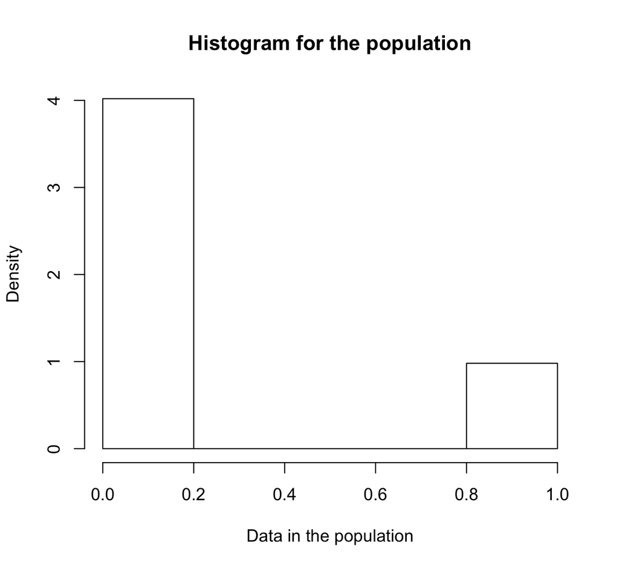

## Law of Large Numbers

The **Law of Large Numbers** (LLN) says that suppose you draw a sample with replacement from a population, as your sample size gets larger and larger the histogram for your **sample** will look more and more similar to the histogram for the **population** that you are drawing from.

In general, in order for the LLN to work the elements in your sample need to be (approximately) **independent and identically distributed** (i.i.d.).

# Understand the probability of the sample outcomes

## What’s the chance that our interval estimate will cover the true population percentage?

For a sample of size 19 the possible point estimates (in percentages) are

```r
round((0:19)/19 * 100, digits = 2)
 [1]   0.00   5.26  10.53  15.79  21.05  26.32  31.58  36.84
 [9]  42.11  47.37  52.63  57.89  63.16  68.42  73.68  78.95
[17]  84.21  89.47  94.74 100.00
```

# Calculate the probability for each possible sample average

**Probability** is interpreted as long term (relative) frequency.

## Some terminology

**Outcome**–An outcome is a possible result of an experiment.

**Events**–An event is a particular outcome or a collection of the outcomes. The “somethings” that we consider the probabilities of are usually called events.

**Outcome space**–The collection of all possible outcomes in a random experiment.

## Rules about probability

- Probability is always between 0 and 1. 0 means impossible to happen and 1 means it will definitely happen;
- The complement of an event A is the entire collection of all possible outcomes excluding A;
- The probability of an event A = 1 - the probability of the complement of the event A.

## Independence

We say that two events are independent if
$$P(A | B) = P(A);$$
otherwise, they are dependent.

## Addition and multiplication rules of probability

For two events A and B
$$P(A & B) = P(A)P(B|A) = P(B)P(A|B)$$

$$P(A or B) = P(A) + P(B) - P(A & B)$$

## Mutually exclusive events

Two events are **mutually exclusive** if the occurrence of one prevents the occurrence of the other: one excludes the other.

Thus, if events A and B are **mutually exclusive** P(A & B) = 0 and
$$P(A\ or\ B) = P(A) + P(B)$$

## Calculate the probability for each possible sample average

### Probability that the sample average is 0

P(sample average is 0) = P(all students in the sample are not athletes)

This probability is $(1-.1955)^{19} = 0.016$.

### Probability that the sample average is 1/19

P(sample average is 0) = P(only 1 student in the sample is an athlete)

This probability is $19(.1955)(1-.1955)^{18} = 0.07$.

### Probability that the sample average is 2/19

This probability is $c(.1955)^{2}(1-.1955)^{17}$ where $c$ is a constant.

### Random Variable

A **random variable** is a variable whose possible values are numerical outcomes of a random phenomenon.

Let $X$ = the number of athletes in a sample of size 19. Then, $X$ is a random variable. The value for $X$ varies and could change if we repeat the experiment. As we see here the number of athletes in the sample varies each time you draw a new sample.

There are two types of random variables, discrete and continuous. In the previous example, $X$ is a **discrete random variable** since it takes distinct values. **Continuous random variable** takes values on a continuous interval.

## Probability histogram for discrete random variables

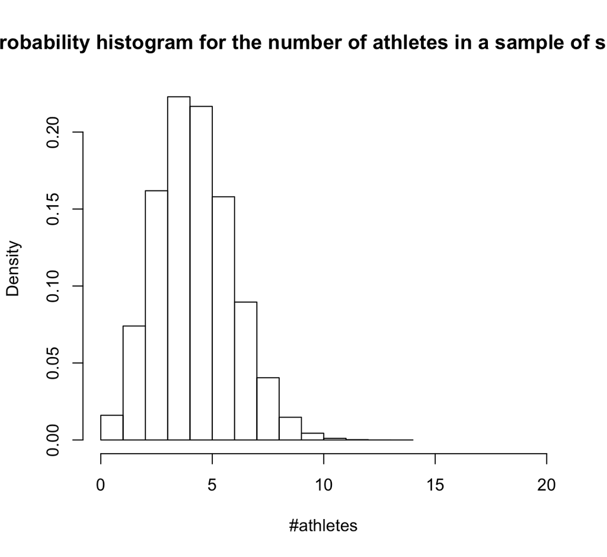

## Independent random variables

For two random variables $X$ and $Y$, we say that they are dependent if knowing the value for one of them actually provide extra information for the value of the other.

### Expectation of a random variable

The average of the values of a random variable is called the *expectation* of the random variable.